# Class 20

## EMMA Starting today

Looking only at the first paragraph

Explaining the notation on the syllabus,

I.1 - Volume 1, Chapter 1 I.18 - Volume 1, Chapter 18

We will be doing both Blake and Emma at the same time.

## Sentiment analysis

There are different ways to attack the problem, we can use dictionaries, can use different dictionaries with different wieghtings

For final, credit will be given for what you are good at.

Circular graph representing sentiment of the bible.

Sentiment dictionaries are hard to make because they take a lot of time.

ANEW dictionary AFINN dictionary - has lots of modern jargon and cursewords, made for twitter, free General Inquirer List - Harvard, has more tags Moral Foundations Dictionary - Made a UVA, has more categories (loyalty, caring,)

Twitter - quickly trying to gage the temperature. Twitter is happy or sad. Then looking for correlation to markets or for advertising. Robots telling robots to buy things.

Irony and sarchasm often cause issues for sentiment analysis.

Today we will work from a sript

```r
# Hacking Class 18: Sentiment Analysis
# April 6, 2020

# Credit where due: some of this code (the Lou's List exercise!) is drawn from Michele Claibourn's R class that I sat in on here at UVa a few years ago!

# Some installs
# install.packages("dplyr")
# install.packages("gtools")

# AFinn Dictionary, named after its creator Finn Ã…rup Nielsen.
# AFINN is a list of English words rated for valence with an integer
# between minus five (negative) and plus five (positive). The words have
# been manually labeled by Finn Ã…rup Nielsen in 2009-2011. The file
# is tab-separated. We're using the newest version: AFINN-111, 2477 words and phrases.

# Set up dictionary
dict<-read.delim("sentanalysis/AFINN-111.txt", header=FALSE, stringsAsFactors=FALSE) # reads a tab-separated file into adataframes
names(dict) <- c('word', 'weight')
View(dict)

# getcorpus should be Rtools.R -- We looked it over yesterday (see notes for Hacking16)
source("RTools.R") #or use your myRTools.R file I sent you a while back
# If you can't find it, I also pasted it in at the bottom of this script.

blakecorpus.l<-getcorpus("songstitled")
str(blakecorpus.l)
```

```
## List of 46
##  $ 1-inn-introduction.txt             : chr [1:121] "piping" "down" "the" "valleys" ...
##  $ 10-inn-laughingsong.txt            : chr [1:100] "when" "the" "green" "woods" ...
##  $ 11-inn-acradlesong.txt             : chr [1:165] "sweet" "dreams" "form" "a" ...
##  $ 12-inn-thedivineimage.txt          : chr [1:107] "to" "mercy" "pity" "peace" ...
##  $ 13-inn-holythursday.txt            : chr [1:95] "is" "this" "a" "holy" ...
##  $ 14-inn-night.txt                   : chr [1:252] "the" "sun" "descending" "in" ...
##  $ 15-inn-spring.txt                  : chr [1:83] "sound" "the" "flute" "now" ...
##  $ 16-inn-nursessong.txt              : chr [1:121] "when" "the" "voices" "of" ...
##  $ 17-inn-infantjoy.txt               : chr [1:51] "i" "have" "no" "name" ...
##  $ 18-inn-adream.txt                  : chr [1:114] "once" "a" "dream" "did" ...
##  $ 19-inn-onanothersorrow.txt         : chr [1:222] "can" "i" "see" "anothers" ...
##  $ 2-inn-theshepherd.txt              : chr [1:61] "how" "sweet" "is" "the" ...
##  $ 20-exp-introduction.txt            : chr [1:90] "hear" "the" "voice" "of" ...
##  $ 21-exp-earthsanswer.txt            : chr [1:107] "earth" "rais'd" "up" "her" ...
```

[output cut: 32 more lines]

dict$word - gets all of the words in the column

length of the poems may have an impact on scoring

Sentiment analysis with context clues could be an interesting project

```r
# Words Scored
dict[which(dict$word %in% blakecorpus.l[[3]]),] # Innocence: A Cradle Song
```

```
##          word weight
## 603   delight      3
## 786    dreams      1
## 1142    happy      3
## 1170   heaven      2
## 1171 heavenly      4
## 1438     like      2
## 1474   lovely      3
## 1554    moans     -2
## 1685    peace      2
## 1720 pleasant      3
## 2055   smiles      2
## 2202    sweet      2
## 2417     weep     -2
```

```r
dict[which(dict$word %in% blakecorpus.l[[18]]),] # Experience: The Little Girl Found
```

```
##           word weight
## 302       bore     -2
## 348       care      2
## 785      dream      1
## 974       fear     -2
## 1457    lonely     -2
## 1551      moan     -2
## 1605        no     -1
## 1716   piteous     -2
## 2080      sore     -1
## 2081    sorrow     -2
## 2093    spirit      1
## 2242     tired     -2
## 2271 trembling     -2
## 2384    vision      1
## 2412      weak     -2
## 2416     weary     -2
## 2417      weep     -2
## 2418   weeping     -2
```

```r
dict[which(dict$word %in% blakecorpus.l[[30]]),] # Experience: The Little Vagabond
```

```
##           word weight
## 566       dear      2
## 991       fire     -2
## 1088       god      1
## 1142     happy      3
## 1166   healthy      2
## 1170    heaven      2
## 1404      kiss      2
## 1438      like      2
## 1605        no     -1
## 1720  pleasant      3
## 1751      pray      1
## 1865 rejoicing      4
## 2401      warm      1
## 2434      wish      1
```

```r
found<-dict[which(dict$word %in% blakecorpus.l[[18]]),]
sum(found$weight)
```

```
## [1] -21
```

```r
cradle.df<-dict[which(dict$word %in% blakecorpus.l[[3]]),]
sum(cradle.df$weight) # returns 23
```

```
## [1] 23
```

```r
# Score some other poems
sweep.df<-dict[which(dict$word %in% blakecorpus.l[["26-exp-thechimneysweeper.txt"]]),]
sum(sweep.df$weight) # -1
```

```
## [1] -1
```

```r
# but this is complicated. In fact, there's a lot of sentiment in this poem.
sum(subset(sweep.df, weight<0)[,2]) # negatives: -11
```

```
## [1] -11
```

```r
sum(subset(sweep.df, weight>0)[,2]) # positives: 10
```

```
## [1] 10
```

```r
# let's think harder about this..

lamb.df<-dict[which(dict$word %in% blakecorpus.l[["4-inn-thelamb.txt"]]),]
sum(lamb.df$weight)
```

```
## [1] 13
```

```r
tyger.df<-dict[which(dict$word %in% blakecorpus.l[["31-exp-thetyger.txt"]]),]
sum(tyger.df$weight)
```

```
## [1] -1
```

The following function generalizes the sentiment analysis making it easier so we don have to go through the process with all poems

```r
# A new function to calculate weights for docs (can be applied across corpuslist).
# Expects texts as bags of words.
get_sentiment_afinn <- function(bagofwords){
  result <- sum(dict[which(dict$word %in% bagofwords), "weight"])
  return(result)
}

# Apply the function to the list of texts to get scores
songs.df<-data.frame(sort(sapply(blakecorpus.l,get_sentiment_afinn))) # Note, sorts most negative to least
songs.df
```

```
##                                     sort.sapply.blakecorpus.l..get_sentiment_afinn..
## 25-exp-thelittlegirlfound.txt                                                    -21
## 43-exp-totirzah.txt                                                              -13
## 18-inn-adream.txt                                                                -11
## 19-inn-onanothersorrow.txt                                                       -11
## 21-exp-earthsanswer.txt                                                          -10
## 37-exp-london.txt                                                                -10
## 38-exp-thehumanabstract.txt                                                       -8
## 9-inn-thelittleboyfound.txt                                                       -7
## 20-exp-introduction.txt                                                           -6
## 24-exp-thelittlegirllost.txt                                                      -6
## 46-exp-adivineimage.txt                                                           -6
## 8-inn-thelittleboylost.txt                                                        -6
## 13-inn-holythursday.txt                                                           -5
## 23-exp-holythursday.txt                                                           -5
## 40-exp-apoisontree.txt                                                            -4
## 27-exp-nursessong.txt                                                             -2
## 39-exp-infantsorrow.txt                                                           -2
## 45-exp-thevoiceoftheancientbard.txt                                               -2
## 16-inn-nursessong.txt                                                             -1
## 26-exp-thechimneysweeper.txt                                                      -1
## 31-exp-thetyger.txt                                                               -1
## 42-exp-alittlegirllost.txt                                                        -1
## 29-exp-thefly.txt                                                                  0
## 30-exp-theangel.txt                                                                0
## 28-exp-thesickrose.txt                                                             1
## 7-inn-thechimneysweeperinn.txt                                                     1
## 33-exp-ahsunflower.txt                                                             2
## 22-exp-theclodandthepebble.txt                                                     3
## 35-exp-thegardenoflove.txt                                                         3
## 44-exp-theschoolboy.txt                                                            3
## 32-exp-myprettyrosetree.txt                                                        4
## 34-exp-thelilly.txt                                                                5
## 14-inn-night.txt                                                                   6
## 41-exp-alittleboylost.txt                                                          6
## 2-inn-theshepherd.txt                                                              9
## 6-inn-theblossom.txt                                                               9
## 15-inn-spring.txt                                                                 10
## 17-inn-infantjoy.txt                                                              10
## 3-inn-theecchoinggreen.txt                                                        10
## 10-inn-laughingsong.txt                                                           13
## 12-inn-thedivineimage.txt                                                         13
## 4-inn-thelamb.txt                                                                 13
## 5-inn-thelittleblackboy.txt                                                       14
## 1-inn-introduction.txt                                                            16
## 36-exp-thelittlevagabond.txt                                                      21
## 11-inn-acradlesong.txt                                                            23
```

## dplyr

dplyr makes things a little bit easier when working with data pandas in python

## gtools

has a function that organizes texts in human order helps with cleaning up data frames

## songs of experience

Are songs of experience less positive or more negative

Dictionaries are cheap and easy, semantics are hard.

```r
# Make it prettier?
# (Using package called dplyr's add_rownames function, which is faster than copying and deleting rownames.)
library("dplyr")
library("gtools")
songs.df<-add_rownames(songs.df,"poem") # deprecated?
colnames(songs.df)[2]<-"AFINNscore"
songsinorder.df<-songs.df[mixedorder(songs.df$poem),] #requires mixedorder() {gtools}
View(songsinorder.df)

mean(songsinorder.df$AFINNscore[1:18]) #6.5
```

```
## [1] 6.5
```

```r
mean(songsinorder.df$AFINNscore[19:45]) # -2.18
```

```
## [1] -2.037037
```

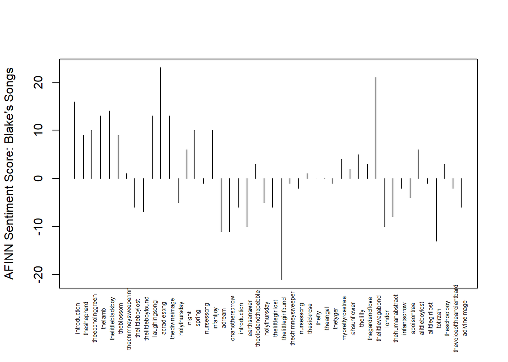

```r
# Songs of Innocence are positive, Songs of Experience are Negative. Well, ok.

plot(rownames(songsinorder.df),songsinorder.df$AFINNscore,
     type="h",
     xaxt="n",
     xlab="",
     ylab="AFINN Sentiment Score: Blake's Songs")
lablist<-gsub(".txt","",songsinorder.df[['poem']])
lablist<-gsub("[0-9]+-[a-z]+-","",lablist)
text(x=1:46,par("usr")[3] - 6,labels = lablist,srt=90,pos=1,offset = .1,xpd=T,cex=.5)
```

```r
#####################################################################
```

```r
# 3. This bit of script borrowed from Michele Claibourn's "Text as Data" class and lightly edited

# library("magrittr")
# library("dplyr")
#
# # Read in downloaded list
# lou1<-read.csv("courses1152Data.csv")
# lou1$number <- as.factor(lou1$Number) # make a new variable containing course number as factor for grouping
# lou1.u <- lou1 %>%   # keep only one record per course (i.e., get rid of "sections/labs" for primary course)
#   group_by(Mnemonic, number) %>%
#   summarize(sections=n(), students=sum(Enrollment), level=first(Number),
#             title=as.character(first(Title)),
#             description=as.character(first(Description)))
# lou1.u <- as.data.frame(lou1.u)
# # Remove columns that end up empty (from my exploration of the data)
# lou1.u <- lou1.u[-c(42,144,956,979,980,1016,1222,1223,1882,2220,2273,2503,2591,2798,2839,2860,2949,2974),]
# # Make separate datasets for graduate and undergraduate courses
# g.lou1 <- subset(lou1.u, level>=5000)
# u.lou1 <- subset(lou1.u, level<5000)
#
# View(u.lou1)
# # create a function to score sentiment for each course/doc -- add processing back in
# get_sentiment <- function(docs){
#   docs <- gsub("[[:punct:]]", "", docs)
#   docs <- gsub("\\d+", "", docs)
#   docs <- tolower(docs)
#   wordList <- strsplit(docs, '\\s+')
#   words <- unlist(wordList)
#   result <- sum(dict[which(dict$word %in% words), "weight"]) # still using AFINN dictionary
#   return(result)
# }
#
# # apply the function to the descriptions
# scores <- sapply(g.lou1$description, get_sentiment)
# hist(scores)
# table(scores)
# summary(scores)
#
# # add sentiment score to data frame for plotting
# g.lou1$sent <- scores
# head(g.lou1)
#
# # most "positive" descriptions in graduate schools (GBUS wins). I got similar results with undergrad: COMM and ARCH
# subset(g.lou1, sent >= 13, select=c(sent, Mnemonic, level, description))
# # most "negative" descriptions in graduate schools (GCOM on fraud, LAW). Similar with undergrad: SOC but also BIOL
# subset(g.lou1, sent <= -7, select=c(sent, Mnemonic, level, description))
#
# # Average sentiment by dept
# g.sent <- g.lou1 %>%
#   group_by(Mnemonic) %>%
#   summarize(meanSent = mean(sent)) %>%
#   arrange(desc(meanSent))
# head(g.sent, 10)
# tail(g.sent, 10)
#
#
# #########
#
# #I'm rerunning for Fall English courses:
# lou2<-read.csv("English1178Data.csv")
# lou2$number <- as.factor(lou2$Number) # course number as factor for grouping
# lou2.u <- lou2 %>%   # keep only one record per course (i.e., get rid of "sections/labs" for primary course)
#   group_by(Mnemonic, number) %>%
#   summarize(sections=n(), students=sum(Enrollment), level=first(Number),
#             title=as.character(first(Title)),
#             description=as.character(first(Description)))
# lou2.u <- as.data.frame(lou2.u)
# View(lou2.u) # no empty columns...
#
# # apply the function to the descriptions
# scores2 <- sapply(lou2.u$description, get_sentiment)
# hist(scores2)
# table(scores2)
# summary(scores2)
#
# # add sentiment score to data frame for plotting
# lou2.u$sent <- scores2
# head(lou2)
#
# # most "positive" descriptions
# subset(lou2.u, sent >= 4, select=c(sent, Mnemonic, level, description))
# # most "negative" descriptions
# subset(lou2.u, sent <= -2, select=c(sent, Mnemonic, level, description))
#
# ################################################################
#
# # Function for importing text files:
# getcorpus<-function(dir,type=".txt"){
#   curr.folder<-getwd()
#   setwd(dir)
#   corpus<-list()
#   files<-list.files(pattern=type)
#   for(i in 1:length(files)){
#     text<-scan(files[i],what="char",sep="\n")
#     text<-paste(text,collapse=" ")
#     lowertext<-tolower(text)
#     text.words<-unlist(strsplit(lowertext,"\\W"))
#     text.words<-text.words[which(text.words!="")]
#     corpus[[files[i]]]<-text.words
#   }
#   setwd(curr.folder)
#   return(corpus)
# }

################################################################

# # Create a Blake Corpus with tm
# library("tm")
# songs<-Corpus(DirSource("songstitled"))
# songs<-tm_map(songs,stripWhitespace)
# songs<-tm_map(songs,content_transformer(tolower))
# songs<-tm_map(songs,removePunctuation)
#
# # Get the words out of tm corpus
# unlist(strsplit(songs[[2]]$content,"\\s"))
#
# ##### Wait, this is more work than it should be!!! #######

# It's simpler in many ways to work with our own functions!
```